# Part I - (Bike Sharing System for San Francisco Bay area)

## Introduction

```python
# import all packages and set plots to be embedded inline
import numpy as np
import pandas as pd
import matplotlib.pyplot as plt
import seaborn as sns

%matplotlib inline
```

```python
bike = pd.read_csv('201902-fordgobike-tripdata.csv')
```

```python
print(bike.shape)
print(           )
print(bike.dtypes)
```

```
(183412, 16)

duration_sec                 int64
start_time                  object
end_time                    object
start_station_id           float64
start_station_name          object
start_station_latitude     float64
start_station_longitude    float64
end_station_id             float64
end_station_name            object
end_station_latitude       float64
end_station_longitude      float64
bike_id                      int64
user_type                   object
member_birth_year          float64
member_gender               object
bike_share_for_all_trip     object
dtype: object
```

```python
bike.info();
```

```
<class 'pandas.core.frame.DataFrame'>
RangeIndex: 183412 entries, 0 to 183411
Data columns (total 16 columns):
 #   Column                   Non-Null Count   Dtype
---  ------                   --------------   -----
 0   duration_sec             183412 non-null  int64
 1   start_time               183412 non-null  object
 2   end_time                 183412 non-null  object
 3   start_station_id         183215 non-null  float64
 4   start_station_name       183215 non-null  object
 5   start_station_latitude   183412 non-null  float64
 6   start_station_longitude  183412 non-null  float64
 7   end_station_id           183215 non-null  float64
 8   end_station_name         183215 non-null  object
 9   end_station_latitude     183412 non-null  float64
 10  end_station_longitude    183412 non-null  float64
 11  bike_id                  183412 non-null  int64
 12  user_type                183412 non-null  object
 13  member_birth_year        175147 non-null  float64
 14  member_gender            175147 non-null  object
 15  bike_share_for_all_trip  183412 non-null  object
dtypes: float64(7), int64(2), object(7)
memory usage: 22.4+ MB
```

```python
bike.describe()
```

|  | duration_sec | start_station_id | start_station_latitude | start_station_longitude | end_station_id | end_station_latitude | end_station_longitude | bike_id | member_birth_year |
| --- | --- | --- | --- | --- | --- | --- | --- | --- | --- |
| count | 183412.000000 | 183215.000000 | 183412.000000 | 183412.000000 | 183215.000000 | 183412.000000 | 183412.000000 | 183412.000000 | 175147.000000 |
| mean | 726.078435 | 138.590427 | 37.771223 | -122.352664 | 136.249123 | 37.771427 | -122.352250 | 4472.906375 | 1984.806437 |
| std | 1794.389780 | 111.778864 | 0.099581 | 0.117097 | 111.515131 | 0.099490 | 0.116673 | 1664.383394 | 10.116689 |
| min | 61.000000 | 3.000000 | 37.317298 | -122.453704 | 3.000000 | 37.317298 | -122.453704 | 11.000000 | 1878.000000 |
| 25% | 325.000000 | 47.000000 | 37.770083 | -122.412408 | 44.000000 | 37.770407 | -122.411726 | 3777.000000 | 1980.000000 |
| 50% | 514.000000 | 104.000000 | 37.780760 | -122.398285 | 100.000000 | 37.781010 | -122.398279 | 4958.000000 | 1987.000000 |
| 75% | 796.000000 | 239.000000 | 37.797280 | -122.286533 | 235.000000 | 37.797320 | -122.288045 | 5502.000000 | 1992.000000 |
| max | 85444.000000 | 398.000000 | 37.880222 | -121.874119 | 398.000000 | 37.880222 | -121.874119 | 6645.000000 | 2001.000000 |

```python
bike.head()
```

|  | duration_sec | start_time | end_time | start_station_id | start_station_name | start_station_latitude | start_station_longitude | end_station_id | end_station_name | end_station_latitude | end_station_longitude | bike_id | user_type | member_birth_year | member_gender | bike_share_for_all_trip |
| --- | --- | --- | --- | --- | --- | --- | --- | --- | --- | --- | --- | --- | --- | --- | --- | --- |
| 0 | 52185 | 2019-02-28 17:32:10.1450 | 2019-03-01 08:01:55.9750 | 21.0 | Montgomery St BART Station (Market St at 2nd St) | 37.789625 | -122.400811 | 13.0 | Commercial St at Montgomery St | 37.794231 | -122.402923 | 4902 | Customer | 1984.0 | Male | No |
| 1 | 42521 | 2019-02-28 18:53:21.7890 | 2019-03-01 06:42:03.0560 | 23.0 | The Embarcadero at Steuart St | 37.791464 | -122.391034 | 81.0 | Berry St at 4th St | 37.775880 | -122.393170 | 2535 | Customer | NaN | NaN | No |
| 2 | 61854 | 2019-02-28 12:13:13.2180 | 2019-03-01 05:24:08.1460 | 86.0 | Market St at Dolores St | 37.769305 | -122.426826 | 3.0 | Powell St BART Station (Market St at 4th St) | 37.786375 | -122.404904 | 5905 | Customer | 1972.0 | Male | No |
| 3 | 36490 | 2019-02-28 17:54:26.0100 | 2019-03-01 04:02:36.8420 | 375.0 | Grove St at Masonic Ave | 37.774836 | -122.446546 | 70.0 | Central Ave at Fell St | 37.773311 | -122.444293 | 6638 | Subscriber | 1989.0 | Other | No |
| 4 | 1585 | 2019-02-28 23:54:18.5490 | 2019-03-01 00:20:44.0740 | 7.0 | Frank H Ogawa Plaza | 37.804562 | -122.271738 | 222.0 | 10th Ave at E 15th St | 37.792714 | -122.248780 | 4898 | Subscriber | 1974.0 | Male | Yes |

### What is the structure of the dataset?

There are 183,412 records in the dataset with 16 features. Using the bike_id variable, there are 4646 bikes in the dataset. Most variables are numeric in nature, some are nominal data(user_type, member_gender and bike_share_for_all_trip), while others are datetime

### What is/are the main feature(s) of interest in your dataset?

when are most trips taken/started in terms of time of day, day of week, month of the year  
What are the number of rdies taken per gender  
How long does the average trip take  
Does the length of the trip depend on the user being a customer of subscriber

### What features in the dataset do you think will help support your investigation into your feature(s) of interest?

The variable that will be most helpful in this analysis are duration_sec, start_time and end_time, user_type and member_gender

## Preliminary Wrangling

I will drop some columns that will not be needed for the analysis  
I will create new columns which will support in analysing the main features of the data set

```python
bike_new = bike.copy()
```

### Adding Columns

```python
# Splitting the start_time column into the variables to form separate columns

bike_new['start_hour'] = pd.to_datetime(bike_new['start_time']).dt.hour
bike_new['start_day'] = pd.to_datetime(bike_new['start_time']).dt.strftime('%a')
bike_new['start_month'] = pd.to_datetime(bike_new['start_time']).dt.strftime('%b')
```

```python
# mapping the hour column inorder to convert it from 24 hour to 12 hour time format

bike_new['start_hour'] = bike_new['start_hour'].map({0:'12AM',1:'1AM', 2:'2AM', 3:'3AM', 4:'4AM', 5:'5AM', 6:'6AM', 7:'7AM',
                                                     8:'8AM', 9:'9AM', 10:'10AM', 11:'11AM', 12: '12PM', 13:'1PM',
                                                     14: '2PM', 15:'3PM', 16: '4PM', 17:'5PM', 18: '6PM', 19:'7PM',
                                                     20: '8PM', 21:'9PM', 22: '10PM', 23:'11PM'})
```

```python
hour_format = ['12AM', '1AM', '2AM', '3AM', '4AM', '5AM', '6AM', '7AM', '8AM', '9AM', '10AM', '11AM', '12PM', '1PM',
               '2PM', '3PM', '4PM', '5PM', '6PM', '7PM', '8PM', '9PM', '10PM', '11PM',]

# Returns the start_hour with the categories and orderedness
start_hour_order = pd.api.types.CategoricalDtype(ordered=True, categories=hour_format)

bike_new['start_hour'] = bike_new['start_hour'].astype(start_hour_order)
```

```python
# Ordering start_day column according to the order of the days of the week
day_format = ['Mon', 'Tue', 'Wed', 'Thu', 'Fri', 'Sat', 'Sun']

# Returns the day_format with the categories and orderedness
day_format_order = pd.api.types.CategoricalDtype(ordered=True, categories=day_format)

bike_new['start_day'] = bike_new['start_day'].astype(day_format_order)
```

```python
#Coverting the time spent riding the bike from sec to minutes
bike_new['duration_min'] = bike_new['duration_sec'].apply(lambda x: x/60).round(2)

# Using this year (2022) i subtracted the birth year from 2022 to get the age of the bike drivers
bike_new['member_age'] = bike_new['member_birth_year'].apply(lambda x: 2022 - x)
```

```python
bike_new.head(1)
```

|  | duration_sec | start_time | end_time | start_station_id | start_station_name | start_station_latitude | start_station_longitude | end_station_id | end_station_name | end_station_latitude | ... | bike_id | user_type | member_birth_year | member_gender | bike_share_for_all_trip | start_hour | start_day | start_month | duration_min | member_age |
| --- | --- | --- | --- | --- | --- | --- | --- | --- | --- | --- | --- | --- | --- | --- | --- | --- | --- | --- | --- | --- | --- |
| 0 | 52185 | 2019-02-28 17:32:10.1450 | 2019-03-01 08:01:55.9750 | 21.0 | Montgomery St BART Station (Market St at 2nd St) | 37.789625 | -122.400811 | 13.0 | Commercial St at Montgomery St | 37.794231 | ... | 4902 | Customer | 1984.0 | Male | No | 5PM | Thu | Feb | 869.75 | 38.0 |

1 rows × 21 columns

### Dropping Columns

```python
# Here i dropped the columns i wont need for the analysis and visualization

drop_cols = ['duration_sec', 'start_station_latitude', 'end_station_latitude', 'start_station_longitude',
             'end_station_longitude', 'start_station_id', 'end_station_id', 'member_birth_year']

bike_new.drop(columns = drop_cols, axis=1, inplace=True)
```

```python
bike_new.head(2)
```

|  | start_time | end_time | start_station_name | end_station_name | bike_id | user_type | member_gender | bike_share_for_all_trip | start_hour | start_day | start_month | duration_min | member_age |
| --- | --- | --- | --- | --- | --- | --- | --- | --- | --- | --- | --- | --- | --- |
| 0 | 2019-02-28 17:32:10.1450 | 2019-03-01 08:01:55.9750 | Montgomery St BART Station (Market St at 2nd St) | Commercial St at Montgomery St | 4902 | Customer | Male | No | 5PM | Thu | Feb | 869.75 | 38.0 |
| 1 | 2019-02-28 18:53:21.7890 | 2019-03-01 06:42:03.0560 | The Embarcadero at Steuart St | Berry St at 4th St | 2535 | Customer | NaN | No | 6PM | Thu | Feb | 708.68 | NaN |

```python
bike_new.dtypes
```

```
start_time                   object
end_time                     object
start_station_name           object
end_station_name             object
bike_id                       int64
user_type                    object
member_gender                object
bike_share_for_all_trip      object
start_hour                 category
start_day                  category
start_month                  object
duration_min                float64
member_age                  float64
dtype: object
```

## Univariate Exploration

I'll start by looking at the distribution of the main variable of interest: Trips taken per day, hour, month and gender.

###### Question: Number and proportion of rides taken per day

[figure not shown]

```python
plt.figure(figsize=(10.5,6))

ax = sns.countplot(x =bike_new['start_day'], color='#da2216')

# code used to add label and proportion to the chart
abs_values = bike_new['start_day'].value_counts()
rel_values = bike_new['start_day'].value_counts(normalize=True).values * 100
lbls = [f'{p[0]} ({p[1]:.1f}%)' for p in zip(abs_values, rel_values)]

plt.ylabel('Number of Rides')
plt.xlabel('Day');
plt.title('THE NUMBER AND PROPORTION OF RIDES TAKEN PER DAY')
ax.bar_label(container=ax.containers[0], labels=lbls);
```

The difference in ratio between other days compared with saturday and sunday shows that more people should be encouraged to participate more on those days.

###### Question: Number and proprtion of rides taken per hour

[figure not shown]

```python
plt.figure(figsize=(7,10))

ax = sns.countplot(y =bike_new['start_hour'], color='#2bab09')

# code used to add label and proportion to the chart
abs_values = bike_new['start_hour'].value_counts()
rel_values = bike_new['start_hour'].value_counts(normalize=True).values * 100
lbls = [f'{p[0]} ({p[1]:.2f}%)' for p in zip(abs_values, rel_values)]

plt.xlabel('Number of Rides')
plt.ylabel('Time')
plt.title('THE NUMBER AND PROPORTION OF RIDES TAKEN PER HOUR')
ax.bar_label(container=ax.containers[0], labels=lbls);
sns.despine();
```

From the charts we can glean that the best time of the day for taken rides are varied between morning, afternoon and evening periods. The periods with the lowest participation are in the early hours of the morning between (12AM - 5AM). The periods of peak participation (top 5) with the highest number of riding activities are 5PM with 21,864 rides which is 11.92% of the total rides. Others are: 8AM (21056, 11.48%), 6PM (16827, 9.17%), 9AM (15903, 8.67%) and 4PM (14169, 7.73%)

###### Question: Rides taken by gender

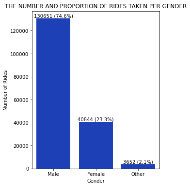

```python
plt.figure(figsize=(4.7,6))

ax = sns.countplot(x =bike_new['member_gender'], color='#0432d1',
                   order=bike_new['member_gender'].value_counts().index)

# code used to add label and proportion to the chart
abs_values = bike_new['member_gender'].value_counts()
rel_values = bike_new['member_gender'].value_counts(normalize=True).values * 100
lbls = [f'{p[0]} ({p[1]:.1f}%)' for p in zip(abs_values, rel_values)]

plt.ylabel('Number of Rides')
plt.xlabel('Gender')
plt.title('THE NUMBER AND PROPORTION OF RIDES TAKEN PER GENDER')
ax.bar_label(container=ax.containers[0], labels=lbls);
```

###### Question: number of trips taken per month and user_type

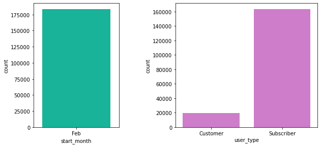

```python
fig, ax = plt.subplots(1, 2, figsize = [10,4.5], gridspec_kw={'width_ratios': [0.3, 0.5]})
plt.subplots_adjust(wspace= 0.5)

sns.countplot(data = bike_new, x = 'start_month', color = '#00ccaa', ax = ax[0])
sns.countplot(data = bike_new, x = 'user_type', color = 'orchid', ax = ax[1]);

#plt.tight_layout();
```

i. start month: From the data, the bar indicates that all the riding activities took place in the month of february

ii. user_type: The chart shows that subscribers are more likely to participate in the bike riding activity compared to the customers. This conclusion is reached as a result of the numerical difference between the two bars and it also shows clear cleavage between the height of the two columns

###### Question: Distribution of the time spent(min) bike riding

```python
bike_new['duration_min'].min(), bike_new['duration_min'].max()
```

```
(1.02, 1424.07)
```

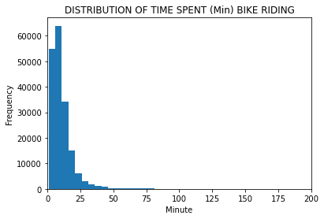

```python
bins = np.arange(1, bike_new['duration_min'].max()+5, 5)
plt.hist(bike_new['duration_min'], bins=bins)

plt.ylabel('Frequency')
plt.xlabel('Minute')
plt.title('DISTRIBUTION OF TIME SPENT (Min) BIKE RIDING')
plt.xlim((0,200));
```

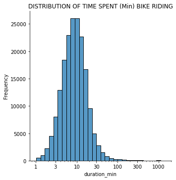

```python
# Here I used a log-scale to accomodate for the outliers
sns.displot(bike_new['duration_min'], log_scale=True, bins=30)
plt.ylabel('Frequency')
plt.title('DISTRIBUTION OF TIME SPENT (Min) BIKE RIDING')

ticks = [1, 3, 10, 30, 100, 300, 1000]
labels = ['{}'.format(v) for v in ticks]
plt.xticks(ticks, labels);
```

###### Question: Distribution of the age of bike riders

```python
bike_new['member_age'].min(), bike_new['member_age'].max()
```

```
(21.0, 144.0)
```

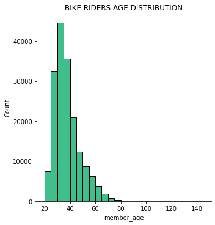

```python
bins = np.arange(20, bike_new['member_age'].max()+5, 5 )

sns.displot(bike_new['member_age'], bins=bins, color='#00aa66')
plt.title('BIKE RIDERS AGE DISTRIBUTION');
```

### Of the features you investigated, were there any unusual distributions? Did you perform any operations on the data to tidy, adjust, or change the form of the data? If so, why did you do this?

- When investigating the dataset, i created a day, time, and month variables from the start_time variable and mapped the time variable from 24hrs to 12hrs time format. Also, i converted the duration from seconds to minutes
- Created an age variable by substracting the birth year from 2022 which was the year this analysis was carried out
- i dropped the columns: duration_sec', 'start_station_latitude', 'end_station_latitude', 'start_station_longitude', 'end_station_longitude', 'start_station_id', 'end_station_id', 'member_birth_year'

## Bivariate Exploration

###### Question: Average duration of trip by user type and gender

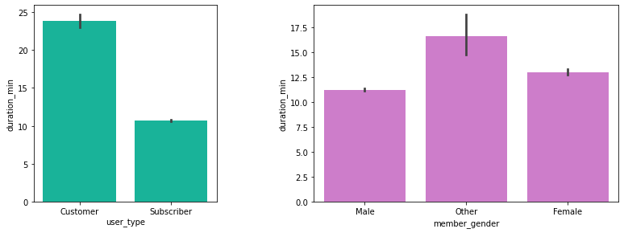

```python
fig, ax = plt.subplots(1, 2, figsize = [13,4.5], gridspec_kw={'width_ratios': [0.3, 0.5]})
plt.subplots_adjust(wspace= 0.4)

sns.barplot(data=bike_new, x='user_type', y='duration_min', color = '#00ccaa', ax = ax[0])
sns.barplot(data=bike_new, x='member_gender', y='duration_min', color = 'orchid', ax = ax[1]);
```

The chart shows the average duration of trips taken by gender and user type. Subscribers on average ride for 10 minutes, while customers ride for approximately 24 minutes. For the gender, other has the highest average time traveled which is 16minutes approximately, while for female 12.5 minutes and for male approximately 11.5 minutes

###### Question: Correlations between quantitative variables (duration and age)

I used a regplot to show the relationship between member_age and duration_min below. Howover because of overploting iI used random sampling to plot a smaller number of points (1000 points)

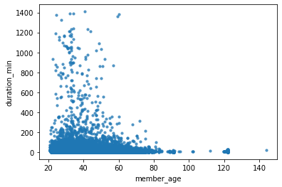

```python
# used x_jitter, alpha and reduced the dot sixe to reduce overplotting
sns.regplot(data=bike_new, x='member_age', y='duration_min', x_jitter= 0.3, scatter_kws={'alpha': 0.7, 's':10}, fit_reg=False);
```

Random sample of 1000 points from the data set to show relationship between member_age and bike ride duration in minutes

```python
bike_subset = bike_new.sample(n=1000, random_state=2)
```

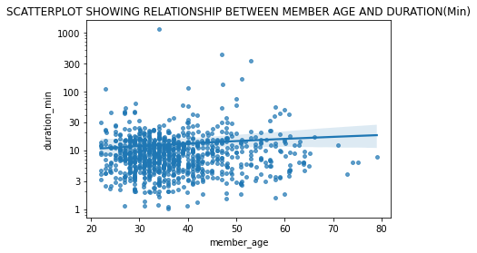

```python
# used x_jitter, alpha and reduced the dot sixe to avoid overplotting
sns.regplot(data= bike_subset, x='member_age', y= 'duration_min', x_jitter= 0.1, scatter_kws={'alpha': 0.7, 's':15})
plt.yscale('log')
plt.title('SCATTERPLOT SHOWING RELATIONSHIP BETWEEN MEMBER AGE AND DURATION(Min)')

ticks = [1, 3, 10, 30, 100, 300, 1000]
labels = ['{}'.format(v) for v in ticks]
plt.yticks(ticks, labels);
```

I used a log scale for the y-axis to lessen out the how outliers might skew the plot. From the scatterplot most of the data points are located between 30 - 40 years and 3 - 15 minutes, indicating the peak of the distribution. The data shows a weak correlation between the variables. That is as one variable increases, there is no set expectation of what the other variable will do

```python
x_vars = ['user_type', 'member_gender']
```

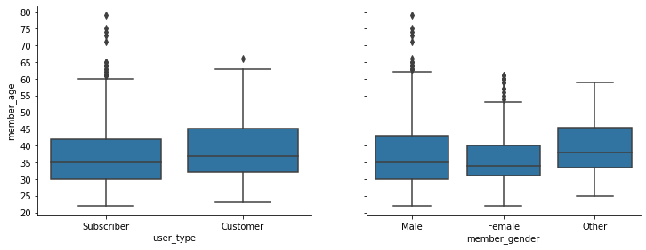

```python
def boxgrid(x, y, **kwargs):
    """ Quick hack for creating box plots with seaborn's PairGrid. """
    default_color = sns.color_palette()[0]
    sns.boxplot(x=x, y=y, color = default_color)

plt.figure(figsize = [9,9])
g = sns.PairGrid(data = bike_subset, y_vars = ['member_age'], x_vars = x_vars,
                height = 4, aspect = 1.3)
g.map(boxgrid)

# I used personal ticks for the y-axis
ticks = [20,25,30,35,40,45,50,55,60,65,70,75,80]
labels = ['{}'.format(v) for v in ticks]
plt.yticks(ticks, labels);

plt.subplots_adjust(wspace= 0.2);
```

i. user_type: The median values of riders that are customers is approximately 37 years, while that for subscribers is 35 years. This shows that the age of riders that are customers are on average higher than those that are subscribers. The top whisker been longer than the bottom shows the age of the members are more concentrated within a narrower range of values than in the top whisker. Also, the amount of outliers show that subscribers have a lot of older members.

ii. member_gender: The median values that are male is 35, for female it is 34 while for other it is 38. This shows that the age of riders that are male are on average higher than those for female. The plot also shows that all the genders have more riders around the lower end of the age distribution.

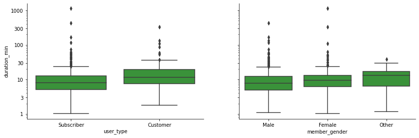

```python
def boxgrid(x, y, **kwargs):
    default_color = sns.color_palette()[2]
    sns.boxplot(x=x, y=y, color = default_color)

plt.figure(figsize = [9,9])
g = sns.PairGrid(data = bike_subset, y_vars = ['duration_min'], x_vars = x_vars,
                height = 4, aspect = 1.5)
g.map(boxgrid)

# I used personal ticks for the y-axis
plt.yscale('log')
ticks = [1, 3, 10, 30, 100, 300, 1000]
labels = ['{}'.format(v) for v in ticks]
plt.yticks(ticks, labels);

plt.subplots_adjust(wspace= 0.2);
```

i. user_type: The median values of riders that are customers is approximately 11 minutes, while that for subscribers is approximately 8 minutes. This shows that the time spent (minutes) bike riding by customers are on average higher than those that are subscribers. The top whisker been shorter than the bottom whisker shows the time spent bike riding are more concentrated within a narrower range of values in the top whisker.

###### Question: Bike riding per day in terms of gender and user type

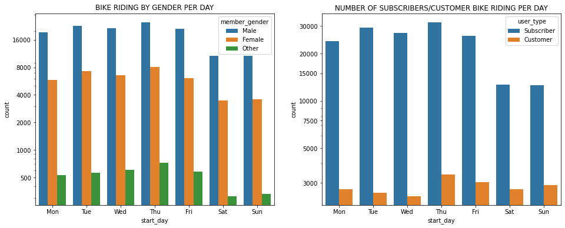

```python
# LEFT plot: count of start day by gender
plt.figure(figsize = [16, 6])

plt.subplot(1, 2, 1)
#Let's return the axes object
ax1 =sns.countplot(data=bike_new, x='start_day', hue='member_gender', hue_order=['Male', 'Female', 'Other'])

plt.title('BIKE RIDING BY GENDER PER DAY')
plt.yscale('log');
ticks = [500, 1000, 2000, 4000, 8000, 16000]
labels = ['{}'.format(v) for v in ticks]
plt.yticks(ticks, labels);

# RIGHT plot: count of user type by day
plt.subplot(1, 2, 2)
sns.countplot(data=bike_new, x='start_day', hue='user_type', hue_order=['Subscriber', 'Customer'])

plt.title('NUMBER OF SUBSCRIBERS/CUSTOMER BIKE RIDING PER DAY');
plt.yscale('log');
ticks = [3000, 5000, 7500, 10000, 15000, 20000, 30000]
labels = ['{}'.format(v) for v in ticks]
plt.yticks(ticks, labels);
```

i. member_gender: the bar shows the different participation of each gender during bike riding and the day each gender prefers to bike ride. For males and females, participation days are in this order from higest to lowest: thursday, tuesday, wednesday, friday, monday, sunday, saturday. The other gender takes a completely different order, which is: thursday, wednesday, friday, tuesday, monday, sunday, saturday. However one thing common for all genders is riders prepare to go bike riding on weekdays than on weekends. Also a larger proportion of riders are male

ii. user_type: an obvious takeaway from the chart is the willingness of customers to come bike riding on weekends. Unlike subscribers who from the bar frequency come mostly on weekdays. The order of bike riding participation for subscribers from highest to lowest is: thursday, tuesday, wednesday, friday, monday, sunday, saturday. For customers, the participation order is: thursday, friday, sunday, monday, saturday, tuesday and wednesday.

##### Question: Th time subscriber or customer go out most for bike riding

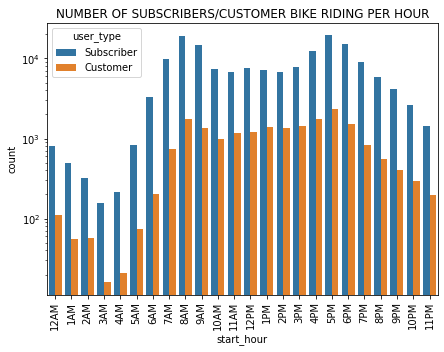

```python
plt.figure(figsize=(7,5))
sns.countplot(data=bike_new, x='start_hour', hue='user_type', hue_order=['Subscriber', 'Customer'])
plt.title('NUMBER OF SUBSCRIBERS/CUSTOMER BIKE RIDING PER HOUR')
plt.xticks(rotation=90);
plt.yscale('log');
```

From the chart a high proportion of riders are subscribers and they mostly go out bike riding during the hours of: 5pm, 8am, 6pm, 9am, 4pm, 7am 7pm. However, the seven most frquent hours customers go out riding are: 5pm, 8am, 4pm, 6pm, 3pm, 1pm, 9am. Both categories share the same low turnout of riders during the hours of: 3am, 4am, 2am, 5am and 1am

##### Question: Time each gender go out most for bike riding

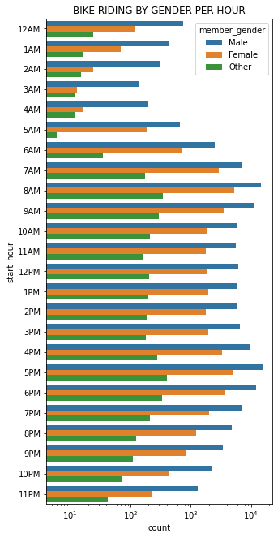

```python
plt.figure(figsize=(5, 11))

sns.countplot(data=bike_new, y='start_hour', hue='member_gender', hue_order=['Male', 'Female', 'Other'])
plt.title('BIKE RIDING BY GENDER PER HOUR')

plt.xscale('log');
```

This chart shows the bike riding preference of each gender in terms of hour of the day. More males and other gender come out around 5pm, then 8am, while more females come out around 8am, then 5pm, after that, they share the same preference for the next top 4 hours of the day they come to bike ride, which are 6pm, 9am and 4pm, 7am  
The hour with the least participation for males is 3am, for female it is 3am, while for other gender it is 5am

### Talk about some of the relationships you observed in this part of the investigation. How did the feature(s) of interest vary with other features in the dataset?

- There is a weak relationship between the age of the ride and the time spend bike riding
- Inteesting the larger the frequency of bike rides taken by gender or user type (customer/subscribers) the smaller the average value of the duration covered.

## Multivariate Exploration

```python
bike_new.head(2)
```

|  | start_time | end_time | start_station_name | end_station_name | bike_id | user_type | member_gender | bike_share_for_all_trip | start_hour | start_day | start_month | duration_min | member_age |
| --- | --- | --- | --- | --- | --- | --- | --- | --- | --- | --- | --- | --- | --- |
| 0 | 2019-02-28 17:32:10.1450 | 2019-03-01 08:01:55.9750 | Montgomery St BART Station (Market St at 2nd St) | Commercial St at Montgomery St | 4902 | Customer | Male | No | 5PM | Thu | Feb | 869.75 | 38.0 |
| 1 | 2019-02-28 18:53:21.7890 | 2019-03-01 06:42:03.0560 | The Embarcadero at Steuart St | Berry St at 4th St | 2535 | Customer | NaN | No | 6PM | Thu | Feb | 708.68 | NaN |

###### Question: scatterplot showing relationship between age, duration and user type

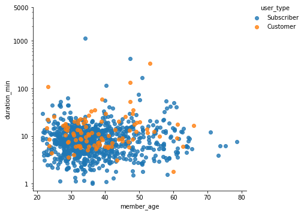

```python
a = sns.FacetGrid(data=bike_subset, hue='user_type', hue_order=['Subscriber', 'Customer'],
                 height=5, aspect=1.2)

a= a.map(sns.regplot, 'member_age', 'duration_min', fit_reg = False, x_jitter=0.4)
a.add_legend(loc='upper right')

plt.yscale('log')

ticks = [1, 10, 100, 1000, 5000]
labels = ['{}'.format(v) for v in ticks]
plt.yticks(ticks, labels);
```

The x-value tracks the age of the rider, the y-value tracks the Overall time (minute) for each ride, and the color tracks which of the two categories of interest the point (customer or subscriber) represents is in. There are outliers that represents more time bike riding for both subscribers and customers. Also, most riders who are above 70 years are subscribers and riders with very low time spent on the riding exercise are mostly subscribers too.

###### Question: scatterplot showing relationship between age, duration and gender

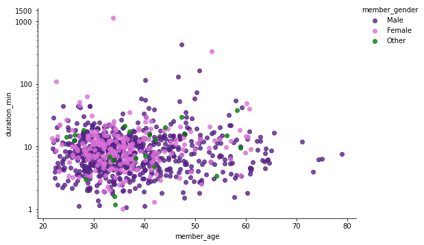

```python
a = sns.FacetGrid(data=bike_subset, hue='member_gender', hue_order=['Male', 'Female', 'Other'],
                 height=5, aspect=1.5,  palette=['#562387', 'orchid', 'green'])

a= a.map(sns.regplot, 'member_age', 'duration_min', fit_reg = False, x_jitter=0.4)
a.add_legend(loc='upper right')

plt.yscale('log')

ticks = [1, 10, 100, 1000, 1500]
labels = ['{}'.format(v) for v in ticks]
plt.yticks(ticks, labels);
```

The x-value tracks the age of the rider, the y-value tracks the Overall time (minute) for each ride, and the color tracks which of the two categories of interest the point (Male, Female, or Other) represents is in. Most riders who are 70 years and above are male, the highest time spent (above 1000 minutes) bike riding was done by a female.

###### Question: FacetGrid showing relationship between age, duration and day

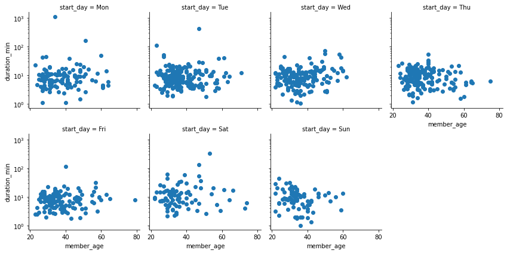

```python
g = sns.FacetGrid(data= bike_subset, col='start_day', col_wrap = 4, height = 3)
g.map(plt.scatter, 'member_age', 'duration_min');

plt.yscale('log');
```

###### Question: barchat showing relationship between user type, gender average duration per min

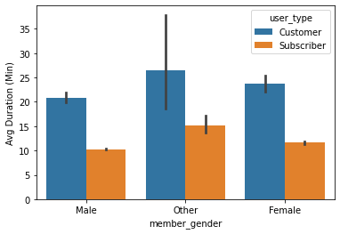

```python
sns.barplot(data=bike_new, x='member_gender', y='duration_min', hue='user_type');
plt.ylabel('Avg Duration (Min)');
```

From the chart customers have a higher average than subscriber in terms of the time spent bike riding, with other gender having a larger average than females and males. This same trend also repeats itself for subscribers too.